# 1. Dataset information and research questions

### 1.1. Read me

For our project, we will analyze Titanic Data. The Royal Mail Ship (RMS) Titanic was a British passenger liner that sank in the North Atlantic Ocean in the early morning of 15 April 1912, after colliding with an iceberg during her maiden voyage from Southampton to New York City (source: [Wikipedia](http://en.wikipedia.org/wiki/RMS_Titanic)). The available dataset was obtained from the [kaggle website](http://www.kaggle.com/c/titanic/data) by Udacity's training staff and instructors. It mainly contains demographics and passenger information from 891 of the 2224 passengers and crew on board of the Titanic.

### 1.2. Variable descriptions

The dataset contains the following information:

- Survival (survival: 0 = No; 1 = Yes)
- Passenger Class (pclass: 1 = 1st; 2 = 2nd; 3 = 3rd)
- Name (name)
- Sex (sex)
- Age (age)
- Number of Siblings/Spouses Aboard (sibsp)
- Number of Parents/Children Aboard (parch)
- Ticket Number (ticket)
- Passenger Fare (fare)
- Cabin (cabin)
- Port of Embarkation (embarked: C = Cherbourg; Q = Queenstown; S = Southampton)

### 1.3. Investigation question

A [BBC Magazine](http://www.bbc.com/news/magazine-17515305) article reporting converging opinions of various experts and investigators sustains that on the RMS Titanic "women and children survived in greater numbers across all classes as they were given priority on the lifeboats".  
To assess the veracity of this affirmation, we will address whether and how the presence of siblings and other first-degree relatives aboard affected the proportion of Titanic passengers surviving, on the assumption that children were travelling (and saved) with their parents.

# 2. Data wrangling

## 2.1. Assessment of data quality

```python
# The following code reads all the Titanic data into
# Pandas DataFrames.

import pandas as pd
import numpy as np

titanic_df = pd.read_csv('titanic_data.csv')
```

```python
# The following code displays Titanic data first 5 lines
titanic_df.head()
```

|  | PassengerId | Survived | Pclass | Name | Sex | Age | SibSp | Parch | Ticket | Fare | Cabin | Embarked |
| --- | --- | --- | --- | --- | --- | --- | --- | --- | --- | --- | --- | --- |
| 0 | 1 | 0 | 3 | Braund, Mr. Owen Harris | male | 22.0 | 1 | 0 | A/5 21171 | 7.2500 | NaN | S |
| 1 | 2 | 1 | 1 | Cumings, Mrs. John Bradley (Florence Briggs Th... | female | 38.0 | 1 | 0 | PC 17599 | 71.2833 | C85 | C |
| 2 | 3 | 1 | 3 | Heikkinen, Miss. Laina | female | 26.0 | 0 | 0 | STON/O2. 3101282 | 7.9250 | NaN | S |
| 3 | 4 | 1 | 1 | Futrelle, Mrs. Jacques Heath (Lily May Peel) | female | 35.0 | 1 | 0 | 113803 | 53.1000 | C123 | S |
| 4 | 5 | 0 | 3 | Allen, Mr. William Henry | male | 35.0 | 0 | 0 | 373450 | 8.0500 | NaN | S |

```python
# Checking data types of our data to assess whether the parameters we are interested in
# are available and usable

titanic_df.dtypes
```

```
PassengerId      int64
Survived         int64
Pclass           int64
Name            object
Sex             object
Age            float64
SibSp            int64
Parch            int64
Ticket          object
Fare           float64
Cabin           object
Embarked        object
dtype: object
```

```python
# Assessing the presence of missing data (NaN)

titanic_df.isnull().sum()
```

```
PassengerId      0
Survived         0
Pclass           0
Name             0
Sex              0
Age            177
SibSp            0
Parch            0
Ticket           0
Fare             0
Cabin          687
Embarked         2
dtype: int64
```

## 2.2. Data quality report

All our parameters seem available and usable:

- survival of Titanic passengers ('Survived'), int64 with values 0 = No; 1 = Yes
- passengers' age ('Age'), float64
- number of siblings aboard ('SibSp'), int64

177 values are missing from the Age column.  
Rows containing these missing data will be dropped when the Age column will be handled

## 2.3. Droping of columns with information not relevant for the study

```python
del titanic_df['Ticket']
del titanic_df['Fare']
del titanic_df['Cabin']
del titanic_df['Name']
del titanic_df['Pclass']
del titanic_df['Sex']
del titanic_df['Parch']
del titanic_df['Embarked']

titanic_df.head()
```

|  | PassengerId | Survived | Age | SibSp |
| --- | --- | --- | --- | --- |
| 0 | 1 | 0 | 22.0 | 1 |
| 1 | 2 | 1 | 38.0 | 1 |
| 2 | 3 | 1 | 26.0 | 0 |
| 3 | 4 | 1 | 35.0 | 1 |
| 4 | 5 | 0 | 35.0 | 0 |

# 3. Study of the correlation between the number of siblings aboard and survival

## 3.1. Data extraction

```python
# Total number of passengers who survived or died
titanic_df.groupby('Survived')['PassengerId'].count()
```

```
Survived
0    549
1    342
Name: PassengerId, dtype: int64
```

```python
# Count of passengers who survived and died grouped according to their number of siblings aboard
D = titanic_df.groupby(['Survived','SibSp'], as_index=False)['PassengerId'].count()
print D
```

```
    Survived  SibSp  PassengerId
0          0      0          398
1          0      1           97
2          0      2           15
3          0      3           12
4          0      4           15
5          0      5            5
6          0      8            7
7          1      0          210
8          1      1          112
9          1      2           13
10         1      3            4
11         1      4            3
```

```python
# Creating a DataFrame including information on the survival of the proportion of people with siblings

dead_numpy_array = np.array(D['PassengerId'][0:7]) # remove the index
dead_pd_series = pd.Series(dead_numpy_array, index = ['0','1','2','3','4','5','6']) # attribute the index

survivors_numpy_array = np.array(D['PassengerId'][7:12]) # removes the index from survivors
survivors_numpy_array = np.append(survivors_numpy_array,[0,0]) # add the value zero to get same size as the dead (7)
survivors_pd_series = pd.Series(survivors_numpy_array, index = ['0','1','2','3','4','5','6']) # attribute the same index as the dead

siblings_number_df = pd.concat([dead_pd_series, survivors_pd_series], axis=1)
siblings_number_df.columns = ['died', 'survived']

siblings_proportion_df = siblings_number_df.div(siblings_number_df.sum())
print 100*siblings_proportion_df
```

```
        died   survived
0  72.495446  61.403509
1  17.668488  32.748538
2   2.732240   3.801170
3   2.185792   1.169591
4   2.732240   0.877193
5   0.910747   0.000000
6   1.275046   0.000000
```

## 3.2. Plot allowing data visualization for data-based predictions/hypotheses

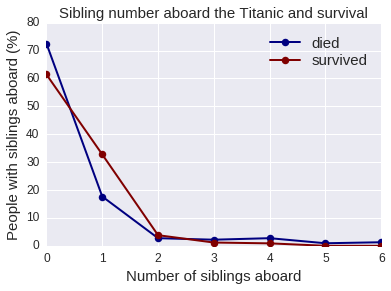

```python
# Plotting the Dataframe for preliminary observations and data-based hypotheses
import matplotlib.pyplot as plt
import seaborn as sns

% pylab inline
ax =(100*siblings_proportion_df).plot(lw=2,colormap='jet',marker='.',markersize=15, fontsize=12)

ax.set_title('Sibling number aboard the Titanic and survival', fontsize=15)
ax.set_xlabel('Number of siblings aboard', fontsize=15)
ax.set_ylabel('People with siblings aboard (%)', fontsize=15)
legend(labelspacing=0.25, fontsize = 15)
```

## 3.4. Re-organizing data to group people with two siblings or more

```python
# Creating a DataFrame including information on the survival of the proportion of people with siblings

dead_numpy_array_2_groups = np.array(D['PassengerId'][0:2]) # remove the index from the dead
dead_numpy_array_1_group = (D['PassengerId'][2:6]).sum() # summing up passenger numbers with more than 2 siblings on board
dead_numpy_array_3_groups = np.append(dead_numpy_array_2_groups, dead_numpy_array_1_group)
dead_pd_series_3_groups = pd.Series(dead_numpy_array_3_groups) # attribute the index

survivors_numpy_array_2_groups = np.array(D['PassengerId'][7:9]) # removes the index from survivors
survivors_numpy_array_1_group = (D['PassengerId'][9:12]).sum() # summing up passenger numbers with more than 2 siblings
survivors_numpy_array_3_groups = np.append(survivors_numpy_array_2_groups, survivors_numpy_array_1_group)
survivors_pd_series_3_groups = pd.Series(survivors_numpy_array_3_groups)

siblings_number_df_3_groups = pd.concat([dead_pd_series_3_groups, survivors_pd_series_3_groups], axis=1)
siblings_number_df_3_groups.columns = ['died', 'survived']

siblings_percent_df = 100*siblings_number_df_3_groups.div(siblings_number_df.sum())

print siblings_percent_df
```

```
        died   survived
0  72.495446  61.403509
1  17.668488  32.748538
2   8.561020   5.847953
```

## 3.5. Additional plotting for current data visualization

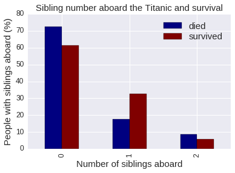

```python
# Plotting the Dataframe for preliminary observations and data-based hypotheses
import matplotlib.pyplot as plt
import seaborn as sns

% pylab inline
ax =(siblings_percent_df).plot.bar(colormap= 'jet', fontsize=12)

ax.set_title('Sibling number aboard the Titanic and survival', fontsize=15)
ax.set_xlabel('Number of siblings aboard', fontsize=15)
ax.set_ylabel('People with siblings aboard (%)', fontsize=15)
legend(labelspacing=0.25, fontsize = 15)
```

## 3.6. Statistical analysis - Chi-square for 2 proportions

Assessement of the significance of differences in proportions between dead people and survivors on the basis of the number of siblings aboard the Titanic

```python
# This function compares two proportions given two values in the same category
from scipy import stats
def proportion_comparator_for_one_df_row(given_np_row):
    matrix_builder = np.array([[dead_pd_series_3_groups.sum(),given_np_row[0]],
                          [survivors_pd_series_3_groups.sum(),given_np_row[1]]])
    return  stats.chi2_contingency(matrix_builder)
```

```python
# This function compares proportions row-wise along the dataframe
def proportion_comparator(siblings_number_df):
    return siblings_number_df.apply(proportion_comparator_for_one_df_row, axis=1) # passes an object row-wise
```

```python
# Running the functions
print proportion_comparator(siblings_number_df_3_groups)
```

```
0    (2.48450912713, 0.11497221412, 1, [[556.943699...
1    (14.8477778645, 0.000116545296539, 1, [[516.81...
2    (1.70517804084, 0.191612192179, 1, [[547.50368...
dtype: object
```

## 3.7. Findings

- passengers with one sibling aboard: the proportion of passenger with 1 sibling aboard who survived was significantly higher than the proportion that died (32.75% vs. 17.67%, p = 0.0001).
- instead, no significant difference was observed in the other groups (passengers without siblings aboard and those with more than 1 sibling aboard)

## 3.8. Emerging hypothesis for further studies

- No clear trend in the difference of proportion between the survivors and the dead passengers was observed based on the presence of siblings (or other first-degree relative) aboard (higher proportion of survivors was observed only in the category of passengers with 1 sibling aboard while in the other extremities, i.e. no siblings or more than 2 siblings, the proportion of survivors was lower than the proportion of dead passengers).
- These observations indicate that the improvement in survival odds of passengers with 1 sibling aboard (conversely, the decrease in the proportion of survivors in the other categories) was the consequence of another factor (for instance parents with one child are faster, thus more likely to join lifeboats, than parents with 2 or more). Notably, in the [BBC Magazine](http://www.bbc.com/news/magazine-17515305) article on the Titanic, experts also argued that "women and children survived in greater numbers across all classes".
- In this regard, in the second part of our project, we will address whether the age of passengers with siblings aboard participated to the improved survivors proportion in the category of passengers with 1 sibling aboard the Titanic.

# 4. Study of the correlation between the passengers' sibling number aboard, the age and survival

## 4.1. Data wrangling

```python
# Verification of the availability of the data of interest
print titanic_df.head()
print ''
print titanic_df.isnull().sum()
```

```
   PassengerId  Survived   Age  SibSp
0            1         0  22.0      1
1            2         1  38.0      1
2            3         1  26.0      0
3            4         1  35.0      1
4            5         0  35.0      0

PassengerId      0
Survived         0
Age            177
SibSp            0
dtype: int64
```

```python
# Copying data to avoid affecting titanic_df eventually
# titanic_df kept for fast comparison, should the necessity emerge
age_df = titanic_df.copy(deep=True)

# Dropping axis labels with missing data
age_df_no_nan = age_df.dropna()

# Assessessment of the success of missing data removal
print age_df_no_nan.isnull().sum()
print ''
age_df_no_nan.head()
```

```
PassengerId    0
Survived       0
Age            0
SibSp          0
dtype: int64
```

|  | PassengerId | Survived | Age | SibSp |
| --- | --- | --- | --- | --- |
| 0 | 1 | 0 | 22.0 | 1 |
| 1 | 2 | 1 | 38.0 | 1 |
| 2 | 3 | 1 | 26.0 | 0 |
| 3 | 4 | 1 | 35.0 | 1 |
| 4 | 5 | 0 | 35.0 | 0 |

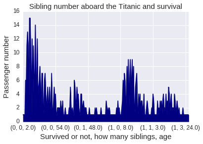

```python
# Average number of passengers who survived or died grouped according to their number of siblings aboard and age
age_no_nan_grouped = age_df_no_nan.groupby(['Survived','SibSp','Age'], as_index=True)['PassengerId'].count()

import matplotlib.pyplot as plt
import seaborn as sns

% pylab inline
ax = age_no_nan_grouped.plot.area(colormap= 'jet', fontsize=12)

ax.set_title('Sibling number aboard the Titanic and survival', fontsize=15)
ax.set_xlabel('Survived or not, how many siblings, age', fontsize=15)
ax.set_ylabel('Passenger number', fontsize=15)
```

## 4.2. Further assessment of data quality

Assessing the age values between 0 and one

```python
# Resetting row index
age_df_no_nan = age_df_no_nan.reset_index(drop=True)

# Age equal to zero
age_df_no_nan[(age_df_no_nan['Age'] == 0)]
```

|  | PassengerId | Survived | Age | SibSp |
| --- | --- | --- | --- | --- |

```python
# Age between 0 and 1
age_df_no_nan[(age_df_no_nan['Age'] < 1) & (age_df_no_nan['Age'] > 0)]
```

|  | PassengerId | Survived | Age | SibSp |
| --- | --- | --- | --- | --- |
| 59 | 79 | 1 | 0.83 | 0 |
| 243 | 306 | 1 | 0.92 | 1 |
| 374 | 470 | 1 | 0.75 | 2 |
| 509 | 645 | 1 | 0.75 | 2 |
| 602 | 756 | 1 | 0.67 | 1 |
| 640 | 804 | 1 | 0.42 | 0 |
| 664 | 832 | 1 | 0.83 | 1 |

### 4.2.1. Observations and course of action

Some passenger are aged between 0 and 1, probably typos.  
Data will be replaced by the value without the 0. e.g. 0.83 will become 83

```python
# Replacing typos 0.x with their value x
# this method also add value 100 to Siblings column. Will be nullified in further steps by using >0
# instead of == 1 while selecting data (see age_data_parser_survivors function below)
age_df_no_nan[(age_df_no_nan['Age'] < 1) & (age_df_no_nan['Age'] > 0)] = 100*(age_df_no_nan[(age_df_no_nan['Age'] < 1) & (age_df_no_nan['Age'] > 0)])

# Verifying that typos were removed
print age_df_no_nan[(age_df_no_nan['Age'] < 1) & (age_df_no_nan['Age'] > 0)]
print ''
print age_df_no_nan['Age'].iloc[59]
print age_df_no_nan['Age'].iloc[243]
print age_df_no_nan['Age'].iloc[374]
```

```
Empty DataFrame
Columns: [PassengerId, Survived, Age, SibSp]
Index: []

83.0
92.0
75.0
```

```python
def checking_typos (age_df_no_nan):
    for i in range (len(age_df_no_nan)):
                       return age_df_no_nan[age_df_no_nan[(age_df_no_nan['Age'] < i+1) & (age_df_no_nan['Age'] > i)] != 0]
```

```python
# Assessing the number of typos remaining (assuming that age in years is an integer)
(checking_typos (age_df_no_nan).isnull().sum()[['Age']]) - len(age_df_no_nan)
```

```
Age    0
dtype: int64
```

### 4.2.2. Report on current data status

No additional typo detected

## 4.3. Data extraction

```python
# Getting the age of survivors and the number of siblings
age_no_nan_survived = age_df_no_nan[age_df_no_nan['Survived'] > 0]#
# Resetting row index
age_no_nan_survived = age_no_nan_survived.reset_index(drop=True)

# Getting the age of survivors and the number of siblings
age_no_nan_died = age_df_no_nan[age_df_no_nan['Survived'] == 0]
# Resetting row index
age_no_nan_died = age_no_nan_died.reset_index(drop=True)
```

```python
# Making sure than both groups have a high number of values
print age_no_nan_survived.head()
print ''
print 'number of survivor values available:', age_no_nan_survived['Age'].count()
print 'number of dead values available:', age_no_nan_died['Age'].count()
```

```
   PassengerId  Survived   Age  SibSp
0            2         1  38.0      1
1            3         1  26.0      0
2            4         1  35.0      1
3            9         1  27.0      0
4           10         1  14.0      1

number of survivor values available: 290
number of dead values available: 424
```

## 4.4. Age distribution among survivors and dead passengers

### 4.4.1. Histograms

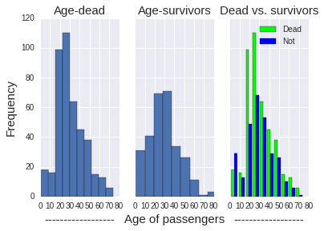

```python
# Plotting age distribution of passengers who died or survived

# Formatting variables for plotting
a = age_no_nan_died['Age']
b = age_no_nan_survived['Age']
c = pd.concat([age_no_nan_died['Age'], age_no_nan_survived['Age']], axis=1)
d = np.array(c)
n_bins = 10

fig, axes = plt.subplots(nrows=1, ncols=3, sharex=True , sharey=True)
ax0, ax1, ax2 = axes.flat

ax0.hist(a, n_bins, normed=0, histtype='bar')
ax0.set_title('Age-dead', fontsize=15)
ax0.set_fontsize=12
ax0.set_xlabel('------------------', fontsize=15)
ax0.set_ylabel('Frequency', fontsize=15)
ax0.set_ylim([0,120])
ax0.set_xlim([0,80])

ax1.hist(b, n_bins, normed=0, histtype='bar')
ax1.set_title('Age-survivors', fontsize=15)
ax1.set_fontsize=12
ax1.set_xlabel('Age of passengers', fontsize=15)

colors = ['lime', 'blue']
ax2.hist(d, n_bins, normed=0, histtype='bar', color=colors, label=['Dead','Not'], stacked=False)
ax2.legend(prop={'size': 10})
ax2.set_title('Dead vs. survivors', fontsize=15)
ax2.set_xlabel('------------------', fontsize=15)
ax2.set_fontsize=12

fig.subplots_adjust(hspace=0.7)
```

## 4.5. Study of sub-groups (ages of passengers grouped by the number of siblings)

```python
# Returns the age of people with a given number of siblings, who survived
def age_data_parser_survivors (low, high, df):
    prser = df[(df['Survived'] > 0) & (df['SibSp'] > low) & (df['SibSp'] < high)]
    return prser.reset_index(drop=True)
```

```python
# Returns the age of people with a given number of siblings, who died
def age_data_parser_dead (low, high, df):
    prser = df[(df['Survived'] == 0) & (df['SibSp'] > low) & (df['SibSp'] < high)]
    return prser.reset_index(drop=True)
```

```python
# Siblings: 0
df = age_no_nan_survived
low = -1
high = 1
age_survived_0 = age_data_parser_survivors (low, high, df)

df = age_no_nan_died
age_died_0 = age_data_parser_dead (low, high, df)

print age_survived_0['Age'].describe()
print ''
print age_died_0['Age'].describe()
```

```
count    175.00000
mean      29.94000
std       13.95984
min        1.00000
25%       21.50000
50%       29.00000
75%       36.00000
max       83.00000
Name: Age, dtype: float64

count    296.000000
mean      32.677365
std       13.486835
min        2.000000
25%       22.000000
50%       29.000000
75%       40.125000
max       74.000000
Name: Age, dtype: float64
```

```python
# Siblings: 1
df = age_no_nan_survived
low = 0
high = 2
age_survived_1 = age_data_parser_survivors (low, high, df)

df = age_no_nan_died
age_died_1 = age_data_parser_dead (low, high, df)

print age_survived_1['Age'].describe()
print ''
print age_died_1['Age'].describe()
```

```
count    94.000000
mean     29.414894
std      15.872076
min       1.000000
25%      19.000000
50%      31.000000
75%      39.000000
max      63.000000
Name: Age, dtype: float64

count    86.000000
mean     31.848837
std      12.235212
min       2.000000
25%      25.000000
50%      30.000000
75%      39.750000
max      70.000000
Name: Age, dtype: float64
```

```python
# Siblings: 2+
df = age_no_nan_survived
low = 1
high = (age_df_no_nan['SibSp'].max())+1
age_survived_2 = age_data_parser_survivors (low, high, df)

df = age_no_nan_died
age_died_2 = age_data_parser_dead (low, high, df)

print age_survived_2['Age'].describe()
print ''
print age_died_2['Age'].describe()
```

```
count    21.000000
mean     34.619048
std      28.817488
min       1.000000
25%      17.000000
50%      24.000000
75%      53.000000
max      92.000000
Name: Age, dtype: float64

count    42.000000
mean     13.666667
std      11.176340
min       1.000000
25%       4.500000
50%       9.500000
75%      20.500000
max      44.000000
Name: Age, dtype: float64
```

## 4.6. Qualitative observation on the age of survivors and dead passengers in function of sibling number

```python
# Building the survival, in function of average age and number of siblings

survival_siblings_age_df = pd.DataFrame(
    data=[[(age_survived_0['Age'].mean()), (age_died_0['Age'].mean())],
          [(age_survived_1['Age'].mean()), (age_died_1['Age'].mean())],
          [(age_survived_2['Age'].mean()), (age_died_2['Age'].mean())]],
    index=['0','1','>2'],
    columns=['Survivors','Dead']
)
```

```
WARNING: pylab import has clobbered these variables: ['axes', 'colors']
`%matplotlib` prevents importing * from pylab and numpy
```

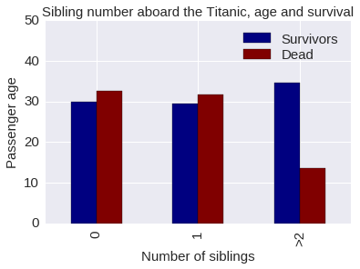

```python
# Plotting the survivors and dead passengers age in function of sibling number
import matplotlib.pyplot as plt
import seaborn as sns

% pylab inline

ax = survival_siblings_age_df.plot.bar(colormap='jet', fontsize=15)

ax.set_title('Sibling number aboard the Titanic, age and survival', fontsize=15)
ax.set_xlabel('Number of siblings', fontsize=15)
ax.set_ylabel('Passenger age', fontsize=15)
ax.set_ylim([0,50])
legend(labelspacing=0.25, fontsize = 15)
```

## 4.7. Observations and hypothesis - Statistical analysis (independent Student t-test)

It seems that most people with 2 sibling aboard who survived where older (about 35 in average) than those who died (about 14 in average)

### 4.7.1. Intergroup comparisons - Dead vs. survivors in groups with same number of siblings aboard

#### 4.7.1.1. No sibling aboard

```python
import pandas as pd
import scipy.stats

# Assessing the statistical significance of diffences in age between survivors and dead with no sibling aboard
print '(survivor mean, standard deviation):', (age_survived_0['Age'].mean(), age_survived_0['Age'].std())
print ''
print '(dead passenger mean, standard deviation):', (age_died_0['Age'].mean(), age_died_0['Age'].std())
print ''
print 'Statistical analysis:', scipy.stats.ttest_ind(age_survived_0['Age'], age_died_0['Age'], axis=0, equal_var=False)
print ''
```

```
(survivor mean, standard deviation): (29.94, 13.959839771171502)

(dead passenger mean, standard deviation): (32.67736486486486, 13.486834552735605)

Statistical analysis: Ttest_indResult(statistic=-2.0823281395485731, pvalue=0.038027692885706101)
```

#### 4.7.1.2. One sibling aboard

```python
# Assessing the statistical significance of diffences in age between survivors and dead with 1 sibling aboard

print '(survivor mean, standard deviation):', (age_survived_1['Age'].mean(), age_survived_1['Age'].std())
print ''
print '(dead passenger mean, standard deviation):', (age_died_1['Age'].mean(), age_died_1['Age'].std())
print ''
print 'Statistical analysis:', scipy.stats.ttest_ind(age_survived_1['Age'], age_died_1['Age'], axis=0, equal_var=False)
print ''
```

```
(survivor mean, standard deviation): (29.414893617021278, 15.872075684915968)

(dead passenger mean, standard deviation): (31.848837209302324, 12.23521190649009)

Statistical analysis: Ttest_indResult(statistic=-1.157613041816119, pvalue=0.24861651592060069)
```

#### 4.7.1.3. Two or more siblings aboard

```python
# Assessing the statistical significance of diffences in age between survivors and dead with 2 or more siblings aboard

print '(survivor mean, standard deviation):', (age_survived_2['Age'].mean(), age_survived_2['Age'].std())
print ''
print '(dead passenger mean, standard deviation):', (age_died_2['Age'].mean(), age_died_2['Age'].std())
print ''
print 'Statistical analysis:', scipy.stats.ttest_ind(age_survived_2['Age'], age_died_2['Age'], axis=0, equal_var=False)
print ''
```

```
(survivor mean, standard deviation): (34.61904761904762, 28.817488076645734)

(dead passenger mean, standard deviation): (13.666666666666666, 11.1763397007111)

Statistical analysis: Ttest_indResult(statistic=3.2132233296387049, pvalue=0.0038466638188140376)
```

#### 4.7.1.4. Findings:

- passengers with no sibling aboard: those who survived where younger than those who died (29.94±13.96 vs. 32.68±13.49, p= 0.038).
- passengers with one sibling aboard: no statistically significant difference in the age was observed (p = 0.24).
- passengers with more than two siblings aboard: those who died were significantly (about two-fold) younger than those who survived (13.67±11.18 vs. 34.62±28.82, p=0.0038)

### 4.7.2. Intra-group comparisons - Groups of survivors with same number of siblings aboard

#### 4.7.2.1. Survivors - One sibling against no sibling

```python
# Assessing the statistical significance of diffences in age between survivors without and with one sibling aboard
print '(No siblings mean, standard deviation):', (age_survived_0['Age'].mean(), age_survived_0['Age'].std())
print ''
print '(One sibling passenger mean, standard deviation):', (age_survived_1['Age'].mean(), age_survived_1['Age'].std())
print ''
print 'Statistical analysis:', scipy.stats.ttest_ind(age_survived_0['Age'], age_survived_1['Age'], axis=0, equal_var=False)
print ''
```

```
(No siblings mean, standard deviation): (29.94, 13.959839771171502)

(One sibling passenger mean, standard deviation): (29.414893617021278, 15.872075684915968)

Statistical analysis: Ttest_indResult(statistic=0.26960054896153096, pvalue=0.78779339564276718)
```

#### 4.7.2.2. Survivors - Two siblings against no sibling

```python
# Assessing the statistical significance of diffences in age between survivors without and with 2+ sibling aboard
print '(No siblings mean, standard deviation):', (age_survived_0['Age'].mean(), age_survived_0['Age'].std())
print ''
print '(Two sibling passenger mean, standard deviation):', (age_survived_2['Age'].mean(), age_survived_2['Age'].std())
print ''
print 'Statistical analysis:', scipy.stats.ttest_ind(age_survived_0['Age'], age_survived_2['Age'], axis=0, equal_var=False)
print ''
```

```
(No siblings mean, standard deviation): (29.94, 13.959839771171502)

(Two sibling passenger mean, standard deviation): (34.61904761904762, 28.817488076645734)

Statistical analysis: Ttest_indResult(statistic=-0.73380501659565489, pvalue=0.4711281919697935)
```

#### 4.7.2.3. Survivors - Two siblings against one

```python
# Assessing the statistical significance of diffences in age between survivors with only one againt 2+ sibling aboard
print '(One sibling mean, standard deviation):', (age_survived_1['Age'].mean(), age_survived_1['Age'].std())
print ''
print '(Two siblings passenger mean, standard deviation):', (age_survived_2['Age'].mean(), age_survived_2['Age'].std())
print ''
print 'Statistical analysis:', scipy.stats.ttest_ind(age_survived_1['Age'], age_survived_2['Age'], axis=0, equal_var=False)
print ''
```

```
(One sibling mean, standard deviation): (29.414893617021278, 15.872075684915968)

(Two siblings passenger mean, standard deviation): (34.61904761904762, 28.817488076645734)

Statistical analysis: Ttest_indResult(statistic=-0.80087459401018068, pvalue=0.43147841128831066)
```

#### 4.7.2.4. Findings - Survivors

No significant difference was observed between ages of survivors with more than 2, only one or no siblings aboard the Titanic (ages were around 30 in all groups)

### 4.7.3. Intra-group comparisons - Groups of dead passengers with same number of siblings aboard

#### 4.7.3.1. Dead - One sibling against no sibling

```python
# Assessing the statistical significance of diffences in age between dead without and with one sibling aboard
print '(No siblings mean, standard deviation):', (age_died_0['Age'].mean(), age_died_0['Age'].std())
print ''
print '(One sibling passenger mean, standard deviation):', (age_died_1['Age'].mean(), age_died_1['Age'].std())
print ''
print 'Statistical analysis:', scipy.stats.ttest_ind(age_died_0['Age'], age_died_1['Age'], axis=0, equal_var=False)
print ''
```

```
(No siblings mean, standard deviation): (32.67736486486486, 13.486834552735605)

(One sibling passenger mean, standard deviation): (31.848837209302324, 12.23521190649009)

Statistical analysis: Ttest_indResult(statistic=0.53987354244308416, pvalue=0.59008369045931042)
```

#### 4.7.3.2. Dead - Two siblings against no sibling

```python
# Assessing the statistical significance of diffences in age between dead without and with 2+ sibling aboard
print '(No siblings mean, standard deviation):', (age_died_0['Age'].mean(), age_died_0['Age'].std())
print ''
print '(Two sibling passenger mean, standard deviation):', (age_died_2['Age'].mean(), age_died_2['Age'].std())
print ''
print 'Statistical analysis:', scipy.stats.ttest_ind(age_died_0['Age'], age_died_2['Age'], axis=0, equal_var=False)
print ''
```

```
(No siblings mean, standard deviation): (32.67736486486486, 13.486834552735605)

(Two sibling passenger mean, standard deviation): (13.666666666666666, 11.1763397007111)

Statistical analysis: Ttest_indResult(statistic=10.035461227542809, pvalue=2.1122879663655081e-14)
```

#### 4.7.3.3. Dead - Two siblings against one

```python
# Assessing the statistical significance of diffences in age between dead with only one againt 2+ sibling aboard
print '(One sibling mean, standard deviation):', (age_died_1['Age'].mean(), age_died_1['Age'].std())
print ''
print '(Two siblings passenger mean, standard deviation):', (age_died_2['Age'].mean(), age_died_2['Age'].std())
print ''
print 'Statistical analysis:', scipy.stats.ttest_ind(age_died_1['Age'], age_died_2['Age'], axis=0, equal_var=False)
print ''
```

```
(One sibling mean, standard deviation): (31.848837209302324, 12.23521190649009)

(Two siblings passenger mean, standard deviation): (13.666666666666666, 11.1763397007111)

Statistical analysis: Ttest_indResult(statistic=8.373668527332816, pvalue=7.7186241348163709e-13)
```

#### 4.7.3.4. Findings - Dead passengers

- No significant difference was observed in terms of age between people without siblings (32.678±13.49 years) and people with only one sibling aboard (31.85±12.26)
- People with two sibling aboard were two-fold younger than the other groups (13.67±11.18, p= 2.11e-14 against passenger without siblings and p= 7.72e-13 against passenger with one sibling aboard)

# 5. Tentative conclusions and Hypothesis for future studies

- No significant difference was observed between survivors and the dead passengers in the category of passengers with one sibling (or other first-degree relative) aboard. Therefore, our data do not support that the priority of boarding for children in lifeboats and the better motility of a parent with one child compared to one with more than 2 children participated to the higher proportion of survivors in the category of passengers with 1 sibling aboard the Titanic.
- Nonetheless, the second part of the study revealed that among passengers with no sibling aboard, those who survived where significantly younger than those who died (29.94±13.96 vs. 32.68±13.49, p < 0.05). Although our data cannot be used to draw strong conclusions, the present finding is in agreement with [experts](http://www.bbc.com/news/magazine-17515305) arguing that there was no orderly evacuation, i.e. survival of the strongest (healthy young adults) was the only rule.
- Not surprisingly and in alignment with this hypothesis (and contrary to [BBC](http://www.bbc.com/news/magazine-17515305) hypothesis of women and children priority for boarding and [Royal navy ethical codes](https://en.wikipedia.org/wiki/Women_and_children_first)), passengers who died were two-fold younger than those who survived (13.67±11.18 vs. 34.62±28.82, p < 0.01). Actually, with an average age of about 14 years old, it appears that passengers with more than 2 siblings aboard who died were mainly children. No other category considered in our study was as young (ages were around 30 in other sibling-based groups).
- For future studies: *(i)* considering that "third class passengers had to find their way through a maze of corridors and staircases to reach the boat deck", and that "less than one third of steerage passengers survived" [BBC](http://www.bbc.com/news/magazine-17515305)", it could be interesting to assess the impact of the socio-economic condition (as revealed by the class in which passengers were traveling) on the proportion of passengers, and mainly children, who survived or died; *(ii)* It could also be interesting to assess the impact of sex, notably the number of women surviving (as they were also supposed to have [priority](https://espace.library.uq.edu.au/view/UQ:152940/HallSSM2261986.pdf)) on the proportion of survivors (or survival odds).

# 6. Code sources

https://sourceforge.net/p/ipython/discussion/markdown_syntax  
http://github.com/adam-p/markdown-here/wiki/Markdown-Here-Cheatsheet  
http://pandas.pydata.org/pandas-docs/stable/missing_data.html  
http://stackoverflow.com/questions/13411544/delete-column-from-pandas-dataframe  
http://pandas.pydata.org/pandas-docs/stable/groupby.html  
http://docs.scipy.org/doc/numpy/reference/generated/numpy.append.html#numpy.append  
http://stackoverflow.com/questions/18062135/combining-two-series-into-a-dataframe-in-pandas  
http://stackoverflow.com/questions/11346283/renaming-columns-in-pandas  
http://stackoverflow.com/posts/13337376/revisions  
http://pandas.pydata.org/pandas-docs/stable/generated/pandas.DataFrame.apply.html  
http://stackoverflow.com/questions/21487329/add-x-and-y-labels-to-a-pandas-plot  
http://stackoverflow.com/questions/7125009/how-to-change-legend-size-with-matplotlib-pyplot  
http://manishamde.github.io/blog/2013/03/07/pandas-and-python-top-10/  
http://stackoverflow.com/questions/13842088/set-value-for-particular-cell-in-pandas-dataframe  
http://stackoverflow.com/questions/20490274/how-to-reset-index-in-a-pandas-data-frame  
http://pandas.pydata.org/pandas-docs/stable/generated/pandas.DataFrame.plot.bar.html  
http://pandas.pydata.org/pandas-docs/stable/generated/pandas.DataFrame.plot.bar.html  
http://pandas.pydata.org/pandas-docs/stable/visualization.html  
http://docs.scipy.org/doc/scipy-0.15.1/reference/generated/scipy.stats.ttest_ind.html  
http://stackoverflow.com/questions/20675534/t-test-on-pandas-dataframes-and-make-a-new-matrix-of-resulting-p-values  
http://docs.scipy.org/doc/scipy/reference/generated/scipy.stats.ttest_ind.html  
http://docs.scipy.org/doc/scipy-0.15.1/reference/generated/scipy.stats.ttest_ind.html  
http://stackoverflow.com/questions/10038543/tracking-down-the-assumptions-made-by-scipys-ttest-ind-function  
http://stackoverflow.com/questions/2849286/python-matplotlib-subplot-how-to-set-the-axis-range  
http://matplotlib.org/examples/pylab_examples/subplots_demo.html  
http://matplotlib.org/examples/statistics/histogram_demo_multihist.html